# The (un)certainty calculator

Demonstration of a tiered approach to refine the characterisation of uncertainty in NGRA exemplified with a risk assessment

Author

Ullrika Sahlin and Dawei Tang

# Introduction

## Uncertainty characterisation

Uncertainty in an assessment is characterised by

1. identifying sources of uncertainty and
2. evaluating their combined impact on the conclusion

## A tiered approach to **reduce** uncertainty

- If practical certainty is not obtained, collect more data

## A tiered approach to **refine** uncertainty

- If practical certainty is not obtained, and it is not justified to collect more data, refine the characterisation of uncertainty
- Follow options for increased refinement until practical certainty is obtained or stop with an inconclusive assessment

### Options to refine the procedure:

- Use worst case assumptions and characterise uncertainty in conclusion directly by expert judgement
- Break down the assessment into parts, characterise uncertainty in each part, combine by calculations, and make expert judgement considering additional sources of uncertainty

### Options to refine the precision:

- Start with probability bounds (Numbers) and combine by Probability Bounds Analysis
- If applicable, proceed with reducing bounds on probabilities
- Otherwise, proceed with specifying full probability distributions and combine by probability calculations or Monte Carlo simulation.

# Assessment

Consider a human health risk assessment of chemical $X$.

uncertainty in a “target human dose” $HD_M^I$ (we denote this by $HD$ in the remaining document)

defined as the human dose at which a fraction I of the population experiences an effect of magnitude (or severity) M or greater

[WHO guidance](https://www.who.int/publications/i/item/9789241513548)

**Warning**

This page is under construction. We are currently working on making a user interface where you can enter your own values on conservative estimates or quantiles representing experts uncertainty about the quantities.

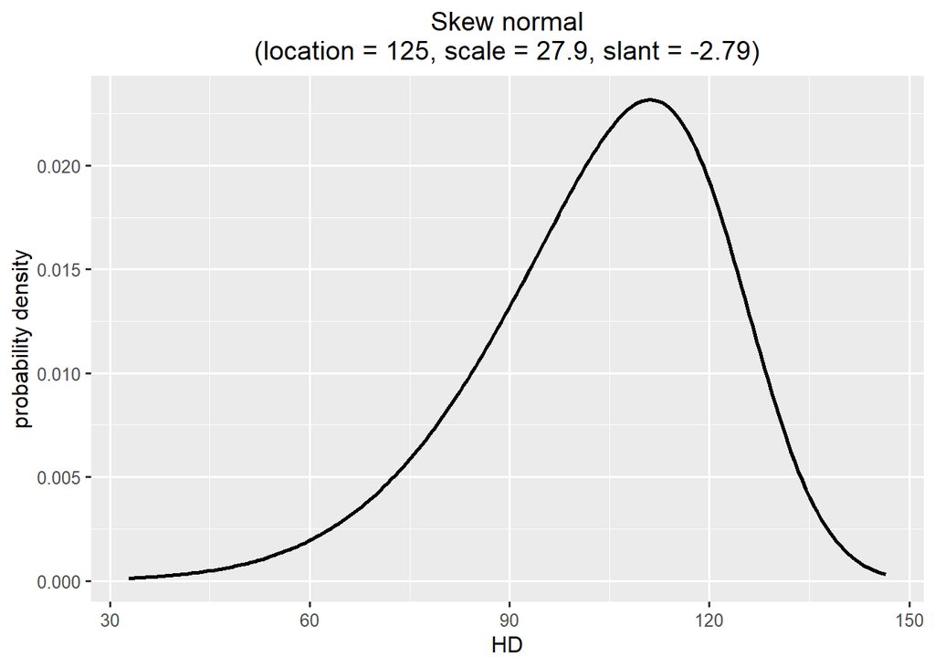

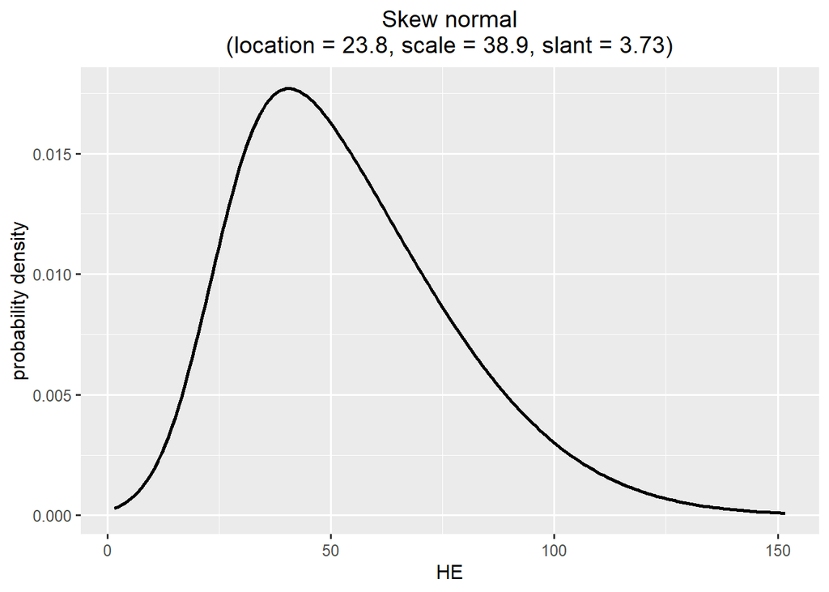

## Hazard assessment

The quantity of interest for the hazard assessment is the Point of Departure, **HD**.

As an example, a HD of 70 μg $X$/kg bw per day was identified by the experts as the BMDL from a model average of BMD modelling for a relevant human effect.

Model Averaged BMD model

| BMDL | BMD | BMDU |
| --- | --- | --- |
| 70 | 106 | 130 |

## Exposure assessment

The quantity of interest for the exposure assessment is a High Exposure in the target population, **HE**.

Estimate of high exposure μg/kg bw per day for compound $X$ is

| HEL | HE | HEU |
| --- | --- | --- |
| 20 | 50 | 100 |

for the given exposure scenario.

## Risk characterisation

The question for the risk assessment is if the High Exposure is below the Point of Departure, i.e.

$$HE < HD$$

The answer to the assessment question is **NO HEALTH CONCERN** if the ratio $\frac{HE}{HD} < 1$.

**Note**

When the HD is derived from BMD modelling, a ratio greater than 1 implies that the exposure can be associated with a 5% increase relative to the background incidence for the effect. Note that the value 5% comes from the definition of HD implemented into the BMD modelling.

## Sources of uncertainty

The first step in an uncertainty analysis is to identify sources of uncertainty related to inputs and methods.

Sources of uncertainty can be summarised as tables with explanations and indications on their influence on the overall uncertainty (qualitative expressions).

# Practical certainty

The practical certainty is by risk managers set to be 80% probability to conclude that compound $X$ is a health concern and 90% probability to conclude that compound $X$ is not a health concern. The assessment is *inconclusive* for any (un)certainty in between the limits.

It can be sufficient to conclude if uncertainty the conclusion is in the range of practical certainty.

| No health concern | Inconclusive | Health concern |
| --- | --- | --- |
| <10% | 10 - 80 | >80% |

or

| Health concern | Inconclusive | No health concern |
| --- | --- | --- |
| <20% | 20 - 90 | >90% |

If not, the assessment should be reported as **inconclusive**. The risk managers can then decide to support generation of new studies to **reduce** uncertainty by collecting more data or perform a re-evaluation of the risk assessment with a more **refined** characterisation of uncertainty.

# A tiered approach to evaluate the combined impact of sources of uncertainty on the conclusion

There are several options to evaluate the combined impact of all these sources of uncertainty on the conclusion whether the risk ratio is greater than 1.

A tiered uncertainty analysis can be done in the following steps

1. Basic option
2. Refined option with uncertainty expressed by probability bounds
3. Refined options with uncertainty expressed by probability distributions

In each step, summarise uncertainty in the conclusion as % probability for the more probable outcome.

Check if the % probability for the more probable outcome is in the region of practical certainty.

# Tier 1. Basic option

The basic option is to assess the combined impact in a single step using expert judgement. This is done by asking the experts to agree how certain they are as a group that $\frac{HE}{HD} < 1$, considering all evidence and all identified (non-standard or standard) sources of uncertainty.

This can be done by reaching a consensus judgement, following procedures for expert knowledge elicitation (using behavioural aggregation to allow for discussions). This judgement requires expertise on both toxicity and exposure assessment.

This judgement is more easy when the conservative estimate for the Highest Exposure is far below (a conservative value for) the Point of Departure (Human Dose). Here

$\frac{HE}{HD} = \frac{100}{70} = 1.4$ which is above the threshold.

Conservative values can be obtained by uncertainty factors. It is preferable to have well-calibrated uncertainty factors as they will result in estimates with known level of conservatism. If not, it is difficult for the experts to judge their uncertainty in the conclusion.

In our example, the expert agree that their (un)certainty lies in the inconclusive range. Some of them say that they can not make this judgement, which would also lead to an inconclusive assessment.

Is practical certainty obtained? No.

We proceed by **refining** uncertainty.

# Tier 2. Refined option with probability bounds

A refined approach is useful when there is a small difference between the Point of Departure (Human Dose) and the Highest Exposure, when the experts cannot conclude and collecting more data is not possible within the limits of the assessment.

A refined option is to assess uncertainties separately for the **HD** and **HE**, combine them by calculations into a risk ratio and assess uncertainty in the conclusion.

We explore how to do this with **probability bound analysis** where we offer two approaches:

- probabilities first: to elicit quantiles for given probabilities, where the probabilities are chosen to obtain practical certainty
- numbers first: to elicit probabilities given numerical values, where the numerical values are chosen so the risk ratio is 1.

We further divide this into two cases: case A where we assess if there is *no health concern* and case B where we assess if there is a *health concern*.

## Case A: Probabilities first, no health concern

The refined option with probability bounds can be modified to consider practical certainty in the following way. In this example, the risk managers and the experts have agreed that experts must be at least 90% certain that a High Exposure **HE** is below the **HD** in order for risk managers to make a decision.

This means that the assessment is conclusive when the experts are at least 90% certain that the risk ratio is less than one (*no health concern*).

Subtract the probability threshold for practical certainty from 100% to set an upper bound for the the sum of the lost probabilities.

$$100\% - 90\% = 10\%$$

Divide the resulting probability into two parts, one for the hazard, here $5\%$, and one for the exposure, what remains $100-90 - 5 = 5\%$.

Elicit the conservative estimate of the Point of Departure (Human Dose) from the toxicology experts (asking them to consider the identified sources of uncertainty for the hazard assessment). Define the conservative estimate as the quantile $y$

$$P(HD < y) = 5\%$$

Here the expert set $y = 70$, which is the BMDL. Experts can adjust this downward or upward considering additional sources of uncertainty.

Elicit a conservative estimate of a High Exposure from the exposure experts (asking them to consider the identified sources of uncertainty for the exposure assessment, alternatively any additional sources of uncertainty not accounted for in a model based conservative estimate). Define the conservative estimate as the quantile $x$

$$P(HE > x) = 5\%$$

In this example, the expert elicit the value $x = 100$.

Divide the conservative estimate for the exposure with the conservative estimate for the hazard $\frac{x}{y}$.

Practical certainty is obtained if $\frac{x}{y} < 1$.

In this example, this ratio is $\frac{100}{70} = 1.4$

Practical certainty is not reached with the probability bounds analysis using probabilities first, proceed with a refined approach.

## Case A: Numbers first, no health concern

Use a conservative estimate for HD as starting point and use experts judgement on their uncertainty for that to guide what value to consider for the exposure part.

Ask experts to judge their probability expressing their uncertainty about a conservative estimate of hazard, e.g. the BMDL.

The experts judge that they are 95% certain that the Point of Departure (Human Dose) is above 70 μg $X$/kg bw per day.

$$P(HD < y) = 5\%$$
That implies that the conservative estimate for the hazard is $y = 70$, which is the BMDL. Experts can adjust this downward or upward considering additional sources of uncertainty.

| P below | value | P above |
| --- | --- | --- |
| 5% | y | 95% |

Derive the value on the High Exposure where the risk ratio is at the critical threshold

$$\frac{x}{y} = 1$$

This value is $x = 1 \cdot y = 70$

Ask the experts to judge their probability that a High Exposure is above 70 μg $X$/kg bw per day. The experts’ elicited probability is 23.5%.

$$P( HE > x) = 23.5\%$$

| P below | value | P above |
| --- | --- | --- |
| 76.5% | x | 23.5% |

Practical certainty is obtained if
$$100 - \min(100, P(HE > x) + P(HD < y)) \geq 90$$
In this example, the left hand side is $100-min(100, 23.5+5)= 71.5$.

Hence, practical certainty is not reached with the probability bounds analysis using numbers first.

If it is not possible to conclude with high enough certainty, we move on to a refined option for uncertainty analysis with probability distributions or consider reducing uncertainty by collecting more data.

**Note**

The numbers and probabilities are chosen for demonstration. There might be inconsistencies in the judgements between the “probability-first” and “numbers-first” approaches in this example. In reality, only one of the options are chosen.

## Case B: Probabilities first, health concern

When a compound has a higher probability to be a health concern, we use the same approaches to assess if it is *conclusively* a health concern.

Consider a compound with a higher **HE** than used in case A:

| HEL | HE | HEU |
| --- | --- | --- |
| 110 | 150 | 220 |

In this example, the risk managers and the experts have agreed that experts must be at least 80% certain that a High Exposure **HE** is *above* the **HD** in order for risk managers to make a decision.

This means that the assessment is conclusive when the experts are at least 80% certain that the risk ratio is greater than one (*health concern*).

Subtract the probability threshold for practical certainty from 100% to set an upper bound for the the sum of the lost probabilities.

$$100\% - 80\% = 20\%$$

Divide the resulting probability into two parts, one for the hazard, here $5\%$, and one for the exposure, what remains $100-80 - 5 = 15\%$.

Elicit the conservative estimate of the Point of Departure (Human Dose) from the toxicology experts (asking them to consider the identified sources of uncertainty for the hazard assessment). Define the conservative estimate as the quantile $y$

$$P(HD > y) = 5\%$$

Here the expert set $y = 130$, which is the BMDU. Experts can adjust this downward or upward considering additional sources of uncertainty.

Elicit a conservative estimate of a High Exposure from the exposure experts (asking them to consider the identified sources of uncertainty for the exposure assessment, alternatively any additional sources of uncertainty not accounted for in a model based conservative estimate). Define the conservative estimate as the quantile $x$

$$P(HE < x) = 15\%$$

In this example, the expert elicit the value $x = 121.8$.

Divide the conservative estimate for the exposure with the conservative estimate for the hazard $\frac{x}{y}$.

Practical certainty is obtained if $\frac{x}{y} > 1$.

In this example, this ratio is $\frac{121.8}{130} = 0.9$

Practical certainty is not reached with the probability bounds analysis using probabilities first, so proceed with a refined approach.

## Case B: Numbers first, health concern

Use a conservative estimate for HD as starting point and use experts’ judgement on their uncertainty for that to guide what value to consider for the exposure part.

Ask experts to judge their probability expressing their uncertainty about a conservative estimate of hazard, e.g. the BMDU.

The experts judge that they are 95% certain that the Point of Departure (Human Dose) is *below* 130 μg $X$/kg bw per day.

$$P(HD > y) = 5\%$$
That implies that the conservative estimate for the hazard is $y = 130$, which is the BMDU. Experts can adjust this downward or upward considering additional sources of uncertainty.

| P below | value | P above |
| --- | --- | --- |
| 95% | y | 5% |

Derive the value on the High Exposure where the risk ratio is at the critical threshold

$$\frac{x}{y} = 1$$

This value is $x = 1 \cdot y = 130$

Ask the experts to judge their probability that a High Exposure is above 130 μg $X$/kg bw per day. The experts’ elicited probability is 75.2%.

$$P( HE < x) = 24.8\%$$

| P below | value | P above |
| --- | --- | --- |
| 24.8% | x | 75.2% |

Practical certainty is obtained if
$$100 - \min(100, P(HE < x) + P(HD > y)) \geq 80$$
In this example, the left hand side is $100-min(100, 24.8+5)= 70.2$.

Hence, practical certainty is not reached with the probability bounds analysis using numbers first.

If it is not possible to conclude with high enough certainty, we move on to a refined option for uncertainty analysis with probability distributions or consider reducing uncertainty by collecting more data.

**Note**

The numbers and probabilities are chosen for demonstration. There might be inconsistencies in the judgements between the “probability-first” and “numbers-first” approaches in this example. In reality, only one of the options is chosen.

# Tier 3. Refined option with probability distributions

A refined option can alternatively be done with probability distributions which are combined by calculations or Monte Carlo simulation.

This is an option, when the outcome of a probability bound analysis was inconclusive.

It can also be an option when the assessors prefers to choose to justify probability distributions for uncertainty from available information, combine uncertainties by performing the probability calculations, and then ask the experts to consider additional sources of uncertainty (not yet accounted for) by making a judgement on the outcome of interest directly.

**Note**

Note that an explicit elicitation of the outcome of interest following a Monte Carlo simulation is a condition for this approach to result in a characterisation of the experts uncertainty considering the combined impact of **all** sources of uncertainty in the assessment.

### Human Dose

A probability distribution representing uncertainty in the **Human Dose** can be taken from the BMD uncertainty distribution generated by bootstrapping or Bayesian modelling. There are plenty of BMD software packages available to do this.

We (the assessors) let the BMDL, the BMD, and the BMDU define a lower percentile (0.05), the median (0.5), and a higher percentile (0.95) of the probability distribution for uncertainty in the **HD**.

|  | BMDL | BMD | BMDU |
| --- | --- | --- | --- |
| P | 5 | 50 | 95 |
| Value | 70 | 106 | 130 |

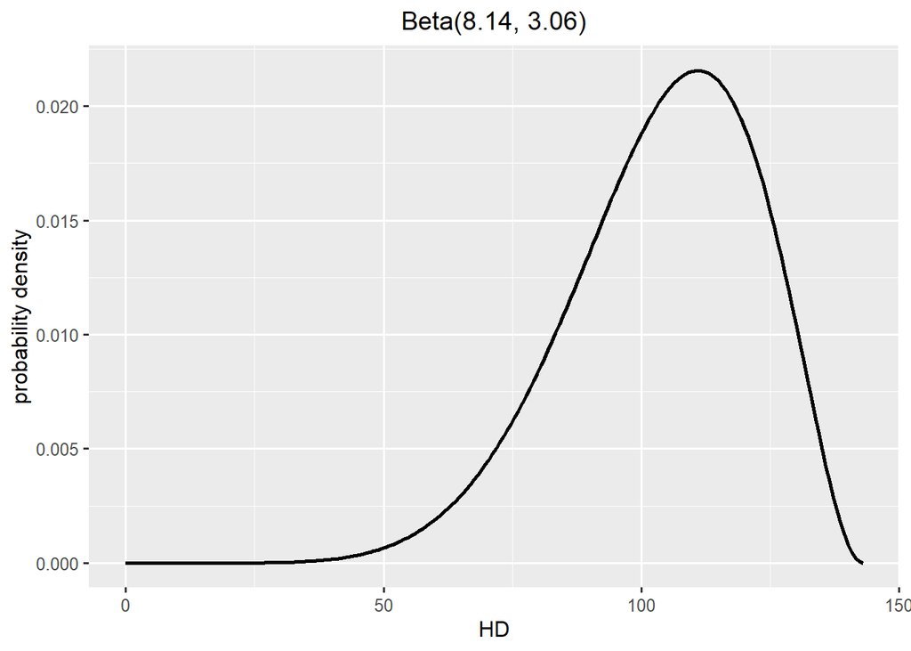

**Warning**

This approach ignores additional sources of uncertainty than those considered in the model, hence we need to draft how to consider those as well. e.g. by adjusting the specification of the quantiles.

### High Exposure

|  | min HE | median HE | max HE |
| --- | --- | --- | --- |
| P | 5 | 50 | 95 |
| value | 20 | 50 | 100 |
| log value | 2.9957323 | 3.912023 | 4.6051702 |

One choice could be to use a lognormal distribution to represent uncertainty in a High Exposure. A lognormal distribution has two parameters, the mean ($\mu$) and the standard deviation ($\sigma$) on the log scale. Note that quantiles are preserved across monotonic transformations.

$$logHE \sim N(\mu,\sigma)$$

$$P95 = \mu + 1.64\cdot \sigma$$

and rearranging it to be a function of $\sigma$

$$\sigma = \frac{P95 - \mu}{1.64} = \frac{4.61-3.91}{1.64}=0.42$$

Specification of the parameters and draw of random numbers from the normal distribution.

[figure not shown]

### Risk evaluation

#### Combine sources of uncertainty by calculations

Evaluate the combined impact of the characterised uncertainty in HD and HE on the risk ratio by Monte Carlo simulation.

The distributions for High Exposure and the Human Dose overlap.

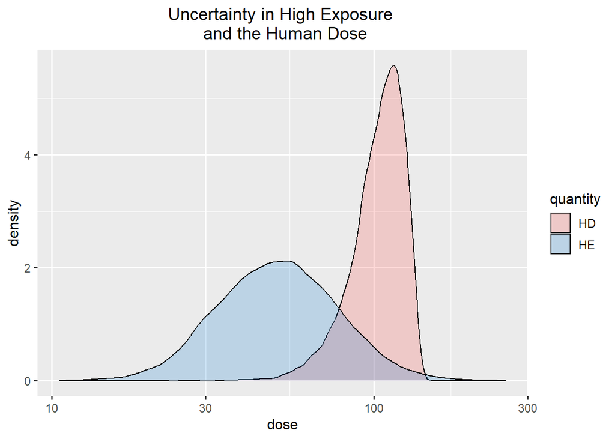

The calculated probability that the risk ratio is below 1 is
$$P(HE<HD)=P(\frac{HE}{HD}<1) = 94 \%$$

This value was derived by calculating the proportion of random samples in your Monte Carlo simulation that corresponds to a ratio < 1.

### Visualisation

Depending on what is the more probable outcome, there are alternatives to visualise uncertainty in the risk ratio: Framing as no health concern and Framing as a health concern. We recommend to choose the framing that corresponds to the more probable outcome.

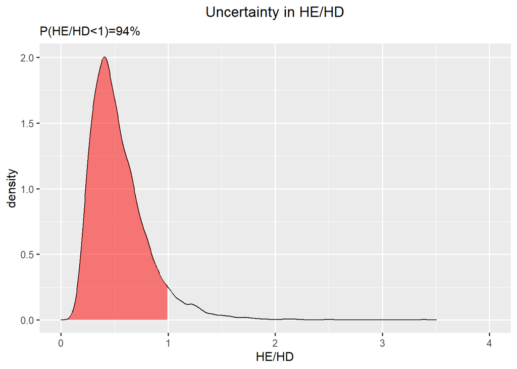

In this visualisation, the red area corresponds to a High Exposure less than the Human Dose.

Another way is to visualise the resulting distribution for uncertainty in the risk ratio by outcome that there is a health concern.

The calculated probability that the risk ratio is above 1 is
$$P(HE>HD)=P(\frac{HE}{HD}>1) = 6 \%$$

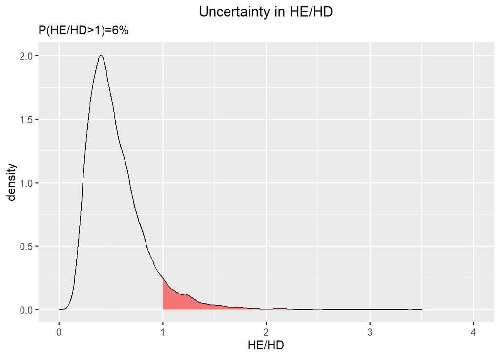

In this visualisation, the red area corresponds to a High Exposure greater than the Human Dose.

### Consider additional sources of uncertainty

As a final step, the experts are invited to adjust this probability upwards or downwards considering **additional sources of uncertainty**, not previously taken into account in the analysis.

An additional sources of uncertainty could e.g. be the choice of distributions used in the Monte Carlo simulation and any limitations in the quality of the exposure and toxicity data that are not taken into account in those distributions.

Experts might judge that any additional sources of uncertainty will have little influence and that there is no need to adjust the calculated % probability that the risk ratio is less (or greater) than 1.

If not, experts can choose to consider any additional uncertainties by adjusting the HD or HE by an uncertainty factor. This factor can be described as a probability distribution or have a single number. It could be factor for exposure and a factor for hazard.

$$P(HE\cdot f_{HE} < HD \cdot f_{HD})$$

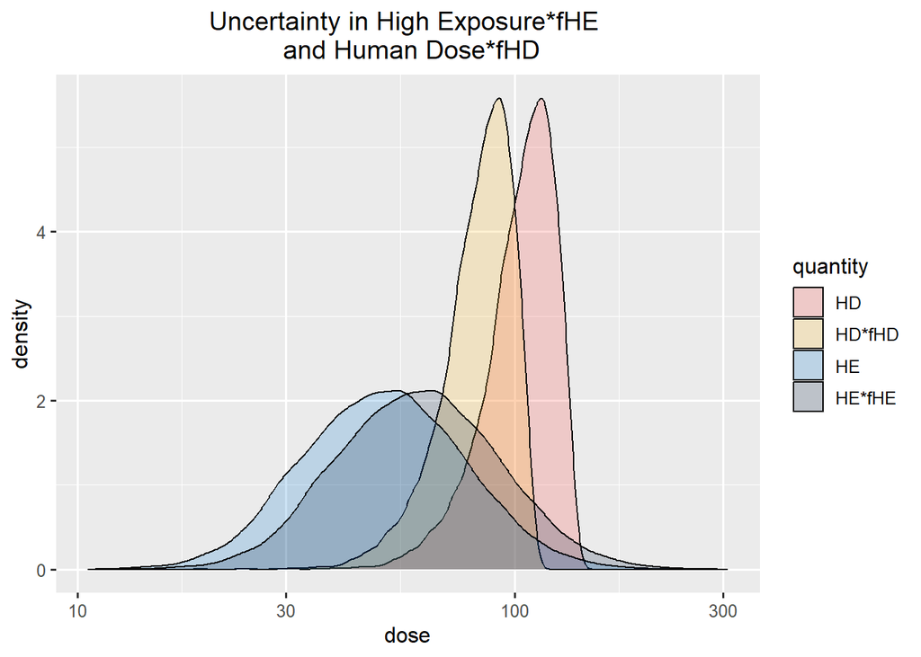

Here the expert judge that their % certainty for no health concern is 75%.

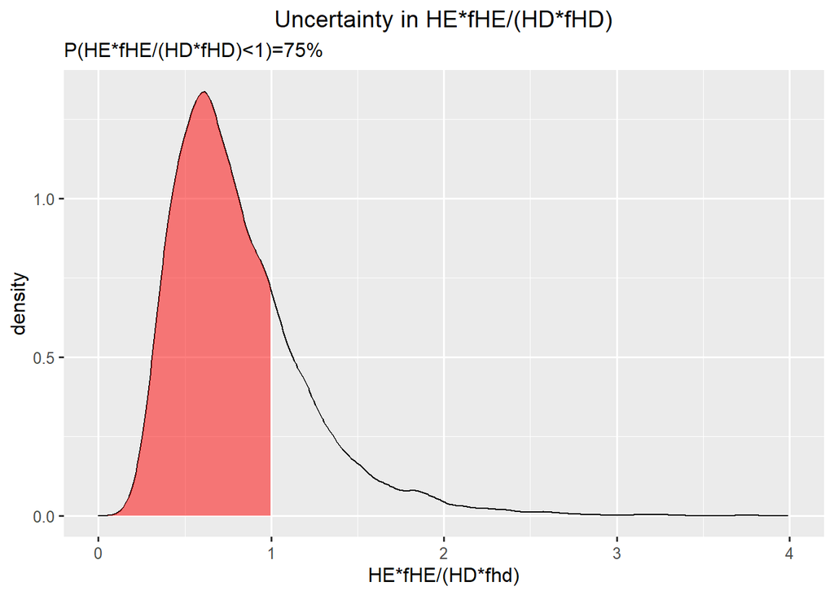

# Comments on the uncertainty framework

Bayesian reasoning combined with Probability bounds analysis can be used for categorical as well as continuous quantities.

Probability bounds can be specified by bounded probability, e.g. $P(HD > y) < 90\%$ instead of $P(HD > y) = 90\%$.

The basic option requires one expert judgement.

The probability bound analysis option requires two expert judgements.

The precise probabilistic option can use information from the probability bound analysis and complement it with at least two more expert judgements. Usually more quantiles are provided from modelling, which in turn is based in multiple expert judgements (for the parameter uncertainty). The probability distributions representing uncertainty in HD and a High Exposure can be more or less derived from quantitative modelling in which uncertainty within the model is characterised, but consideration of additional sources of uncertainty e.g. as multiplication factors is always needed.